# Blunt-nosed Leopard Lizard Data Analysis: Water Physiology Nuances

## Plots

### CEWL ~ Osmolality

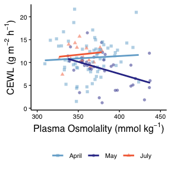

```r
ggplot(dat) +
  aes(x = osmolality_mmol_kg_mean,
      y = CEWL_g_m2h,
      color = month,
      shape = month
      ) +
  geom_point(alpha = 0.5) +
  stat_smooth(formula = y ~ x,
              method = "lm",
              se = F,
              alpha = 0.8) +
  scale_color_manual(values = n3, name = NULL
                     #name = "Measurement\nPeriod"
                     ) +
  scale_shape_manual(values = c(15, 16, 17), name = NULL) +
  labs(x = bquote('Plasma Osmolality (mmol '*kg^-1*')'),
       y = bquote('CEWL (g '*m^-2*' '*h^-1*')')) +
  scale_x_continuous(limits = c(300, 450),
                     breaks = c(300, 350, 400, 450),
                     labels = c(300, 350, 400, 450)) +
  savs_ggplot_theme -> CEWL_osml_fig
CEWL_osml_fig
```

```r
# arrange to get legend centered
ggarrange(CEWL_osml_fig,
          ncol = 1, nrow = 1,
          common.legend = TRUE,
          legend = "bottom"
          ) -> CEWL_osml_fig_arrange
```

```r
# export figure
ggsave(filename = "CEWL_osml_fig.pdf",
       plot = CEWL_osml_fig_arrange,
       path = "./results_figures",
       device = "pdf",
       dpi = 600,
       units = "mm",
       width = 80, height = 80)
```

### CEWL ~ SMI

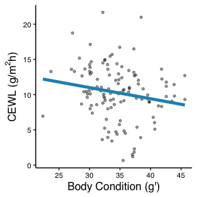

```r
ggplot(dat) +
  aes(x = SMI,
      y = CEWL_g_m2h,
      #color = tmt
      #color = month_sex
      ) +
  geom_point(size = 1,
             alpha = 0.4) +
  stat_smooth(formula = y ~ x,
              method = "lm",
              se = F,
              size = 1.6,
              alpha = 1,
              color = n1) +
  xlab("Body Condition (g')") +
  ylab(bquote('CEWL (g/'*m^2*'h)')) +
  savs_ggplot_theme -> CEWL_SMI_fig
CEWL_SMI_fig
```

### CEWL ~ Hematocrit

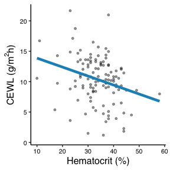

```r
ggplot(dat) +
  aes(x = hematocrit_percent,
      y = CEWL_g_m2h,
      #color = tmt
      #color = month_sex
      ) +
  geom_point(size = 1,
             alpha = 0.4) +
  stat_smooth(formula = y ~ x,
              method = "lm",
              se = F,
              size = 1.6,
              alpha = 1,
              color = n1) +
  xlab("Hematocrit (%)") +
  ylab(bquote('CEWL (g/'*m^2*'h)')) +
  #ylab("") +
  #xlim(300, 450) +
  #annotate(geom = "text", x = 430, y = 24, label = bquote(''*R^2*'=0.033'),
   #        size = 7) +
  #ylim(0, 25) +
  savs_ggplot_theme -> CEWL_hct_fig
CEWL_hct_fig
```

### Osmol ~ SMI

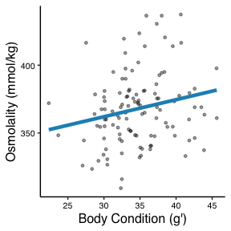

```r
ggplot(dat) +
  aes(x = SMI,
      y = osmolality_mmol_kg_mean,
      #color = tmt
      #color = month_sex
      ) +
  geom_point(size = 1,
             alpha = 0.4) +
  stat_smooth(formula = y ~ x,
              method = "lm",
              se = F,
              size = 1.6,
              alpha = 1,
              color = n1) +
  xlab("Body Condition (g')") +
  ylab("Osmolality (mmol/kg)") +
  #ylab("") +
  #xlim(300, 450) +
  #annotate(geom = "text", x = 430, y = 24, label = bquote(''*R^2*'=0.033'),
   #        size = 7) +
  #ylim(0, 25) +
  savs_ggplot_theme -> osml_SMI_fig
osml_SMI_fig
```

### Osmol ~ Hematocrit

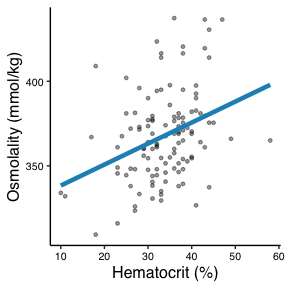

```r
ggplot(dat) +
  aes(x = hematocrit_percent,
      y = osmolality_mmol_kg_mean,
      #color = tmt
      #color = month_sex
      ) +
  geom_point(size = 1,
             alpha = 0.4) +
  stat_smooth(formula = y ~ x,
              method = "lm",
              se = F,
              size = 1.6,
              alpha = 1,
              color = n1) +
  xlab("Hematocrit (%)") +
  ylab("Osmolality (mmol/kg)") +
  #ylab("") +
  #xlim(300, 450) +
  #annotate(geom = "text", x = 430, y = 24, label = bquote(''*R^2*'=0.033'),
   #        size = 7) +
  #ylim(0, 25) +
  scale_color_manual(values = n1) +
  savs_ggplot_theme -> osml_hct_fig
osml_hct_fig
```

### Hct ~ SMI

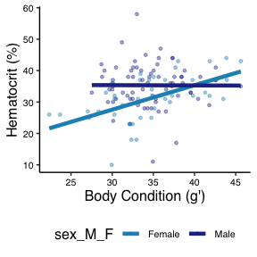

```r
ggplot(dat) +
  aes(x = SMI,
      y = hematocrit_percent,
      color = sex_M_F,
      #color = month_sex
      ) +
  geom_point(size = 1,
             alpha = 0.4) +
  stat_smooth(formula = y ~ x,
              method = "lm",
              se = F,
              size = 1.6,
              alpha = 1) +
  xlab("Body Condition (g')") +
  ylab("Hematocrit (%)") +
  #ylab("") +
  #xlim(300, 450) +
  #annotate(geom = "text", x = 430, y = 24, label = bquote(''*R^2*'=0.033'),
   #        size = 7) +
  #ylim(0, 25) +
  scale_color_manual(values = n2) +
  savs_ggplot_theme -> hct_SMI_fig
hct_SMI_fig
```

# Supplemental Hydration Treatment Effects

We tried to give the lizards water to drink. Did they actually drink any? And did it affect measurable change in their physiology?

## Calculate Deltas

First, calculate the change in CEWL, osmolality, and mass for each treatment individual that was recaptured between April and May.

```r
# get the intitial values from April
starting_values <- dat_repeats %>%
  # look only at lizards in hydration or sham tmt
  dplyr::filter(tmt != "No Tmt") %>%
  # get the values for April measurements only
  dplyr::filter(month == "April") %>%
  dplyr::select(individual_ID,
                CEWL_April = CEWL_g_m2h,
                osml_April = osmolality_mmol_kg_mean,
                mass_April = mass_g)

# calculate deltas
dat_tmt_change <- dat_repeats %>%
  # look only at lizards in hydration or sham tmt
  dplyr::filter(tmt != "No Tmt") %>%
  # add starting values
  left_join(starting_values, by = 'individual_ID') %>%
  # make sure we have complete data
  dplyr::filter(complete.cases(mass_April, CEWL_April)) %>%
  # calculate difference for each msmt versus in April
  mutate(mass_change_from_April = mass_g - mass_April,
         CEWL_change_from_April = CEWL_g_m2h - CEWL_April,
         osml_change_from_April = osmolality_mmol_kg_mean - osml_April)

# subset of data to look at change April->May only
dat_tmt_change_May_only <- dat_tmt_change %>%
  dplyr::filter(month == "May")
```

## Tmt Effect Check

What was mass change *during* treatment, when we either gave lizards water to drink or a sham treatment?

This quantifies the difference in mass gain/loss when we gave them water to drink versus sham treatment.

```r
tmt_effect_mass <- dat %>%
  dplyr::filter(tmt != "No Tmt") %>%
  dplyr::filter(complete.cases(tmt_mass_change_g))
summary(tmt_effect_mass)
```

```
##  capture_date_time                 capture_date        radio_collar_serial
##  Min.   :2021-04-23 03:39:00.00   Min.   :2021-04-23   Length:61
##  1st Qu.:2021-04-23 07:54:00.00   1st Qu.:2021-04-23   Class :character
##  Median :2021-04-24 03:49:00.00   Median :2021-04-24   Mode  :character
##  Mean   :2021-04-28 02:55:24.21   Mean   :2021-04-28
##  3rd Qu.:2021-05-07 04:31:00.00   3rd Qu.:2021-05-07
##  Max.   :2021-05-08 07:19:00.00   Max.   :2021-05-08
##  NA's   :4
##   PIT_tag_ID        individual_ID   sex_M_F       mass_g          SVL_mm
##  Length:61          F-01   : 2    Female:29   Min.   :26.00   Min.   : 85
##  Class :character   F-05   : 2    Male  :32   1st Qu.:33.00   1st Qu.: 95
##  Mode  :character   F-06   : 2                Median :38.00   Median : 99
##                     F-11   : 2                Mean   :39.38   Mean   :101
##                     F-12   : 2                3rd Qu.:46.00   3rd Qu.:108
##                     F-13   : 2                Max.   :56.00   Max.   :122
##                     (Other):49
##         tmt     tmt_mass_change_g capture_to_msmt  hematocrit_percent
##  Water Tmt:29   Min.   :-3.0000   Min.   :  11.0   Min.   :17.00
##  Sham Tmt :32   1st Qu.:-1.0000   1st Qu.:  62.0   1st Qu.:29.75
##  No Tmt   : 0   Median : 0.0000   Median : 150.0   Median :36.00
##                 Mean   :-0.2262   Mean   : 403.5   Mean   :34.30
##                 3rd Qu.: 0.0000   3rd Qu.: 266.0   3rd Qu.:39.00
##                 Max.   : 3.0000   Max.   :1665.0   Max.   :58.00
##                                   NA's   :4        NA's   :1
##  cloacal_temp_C    CEWL_g_m2h      msmt_temp_C    msmt_RH_percent
##  Min.   :24.00   Min.   : 0.650   Min.   :19.07   Min.   :12.20
##  1st Qu.:32.00   1st Qu.: 6.490   1st Qu.:28.57   1st Qu.:14.53
##  Median :33.00   Median : 9.318   Median :30.50   Median :18.73
##  Mean   :32.44   Mean   : 9.410   Mean   :29.43   Mean   :19.45
##  3rd Qu.:34.00   3rd Qu.:10.827   3rd Qu.:31.86   3rd Qu.:22.46
##  Max.   :36.00   Max.   :21.673   Max.   :33.55   Max.   :35.83
##
##     e_s_kPa       msmt_VPD_kPa   osmolality_mmol_kg_mean   month    week
##  Min.   :2.205   Min.   :1.415   Min.   :309.3           April:39   1 :39
##  1st Qu.:3.907   1st Qu.:3.014   1st Qu.:346.1           May  :22   3 :22
##  Median :4.365   Median :3.685   Median :364.2           July : 0   12: 0
##  Mean   :4.168   Mean   :3.396   Mean   :366.5
##  3rd Qu.:4.717   3rd Qu.:4.028   3rd Qu.:381.1
##  Max.   :5.188   Max.   :4.319   Max.   :436.5
##                                  NA's   :1
```

[output cut: 17 more lines]

```
##  Min.   :1.000   Min.   :27.04   April Female:19   Apr 23-25:39
##  1st Qu.:2.000   1st Qu.:32.99   April Male  :20   May 7-9  :22
##  Median :2.000   Median :34.76   May Female  :10   Jul 14   : 0
##  Mean   :2.667   Mean   :35.40   May Male    :12
##  3rd Qu.:3.000   3rd Qu.:38.39   July Female : 0
##  Max.   :5.000   Max.   :45.63   July Male   : 0
##  NA's   :46
##  percent_water_mass_change
##  Min.   :-6.8337
##  1st Qu.:-2.7027
##  Median : 0.0000
##  Mean   :-0.5594
##  3rd Qu.: 0.0000
##  Max.   :10.0000
##
```

```r
# change in grams (actual amount of water "drank")
tmt_change <- lm(data = tmt_effect_mass, tmt_mass_change_g ~ tmt)
summary(tmt_change)
```

```
##
## Call:
## lm(formula = tmt_mass_change_g ~ tmt, data = tmt_effect_mass)
##
## Residuals:
##     Min      1Q  Median      3Q     Max
## -2.2344 -0.3690 -0.2344  0.6656  3.7656
##
## Coefficients:
##             Estimate Std. Error t value Pr(>|t|)
## (Intercept)   0.3690     0.2090   1.765 0.082666 .
## tmtSham Tmt  -1.1346     0.2886  -3.932 0.000224 ***
## ---
## Signif. codes:  0 '***' 0.001 '**' 0.01 '*' 0.05 '.' 0.1 ' ' 1
##
## Residual standard error: 1.125 on 59 degrees of freedom
## Multiple R-squared:  0.2076, Adjusted R-squared:  0.1942
## F-statistic: 15.46 on 1 and 59 DF,  p-value: 0.0002241
```

```r
emmeans(tmt_change, "tmt")
```

```
##  tmt       emmean    SE df lower.CL upper.CL
##  Water Tmt  0.369 0.209 59  -0.0492    0.787
##  Sham Tmt  -0.766 0.199 59  -1.1637   -0.368
##
## Confidence level used: 0.95
```

```r
# change in percent body mass (relative amount)
percent_change <- lm(data = tmt_effect_mass, percent_water_mass_change ~ tmt)
summary(percent_change)
```

```
##
## Call:
## lm(formula = percent_water_mass_change ~ tmt, data = tmt_effect_mass)
##
## Residuals:
##     Min      1Q  Median      3Q     Max
## -5.4465 -1.4239 -0.8996  1.8787 11.9094
##
## Coefficients:
##             Estimate Std. Error t value Pr(>|t|)
## (Intercept)   0.9303     0.5617   1.656 0.102997
## tmtSham Tmt  -2.8397     0.7756  -3.661 0.000538 ***
## ---
## Signif. codes:  0 '***' 0.001 '**' 0.01 '*' 0.05 '.' 0.1 ' ' 1
##
## Residual standard error: 3.025 on 59 degrees of freedom
## Multiple R-squared:  0.1852, Adjusted R-squared:  0.1713
## F-statistic: 13.41 on 1 and 59 DF,  p-value: 0.0005376
```

```r
emmeans(percent_change, "tmt")
```

```
##  tmt       emmean    SE df lower.CL upper.CL
##  Water Tmt   0.93 0.562 59   -0.194    2.054
##  Sham Tmt   -1.91 0.535 59   -2.979   -0.839
##
## Confidence level used: 0.95
```

# Change Over Time

Did hydric physiology change throughout these lizards’ active season? Based on hydration treatment? Sex?

## Plot Change ~ Tmt

### Mass

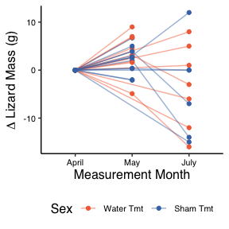

```r
ggplot(dat_tmt_change) +
  aes(x = month,
      y = mass_change_from_April,
      group = individual_ID,
      color = tmt
      ) +
  xlab("Measurement Month") +
  ylab(expression(Delta ~ 'Lizard Mass (g)')) +
  geom_line(alpha = 0.5) +
  geom_point(size = 1.5) +
  scale_color_manual(values = my_colors, name = "Sex") +
  savs_ggplot_theme -> tmt_delta_mass
tmt_delta_mass
```

### Osmolality

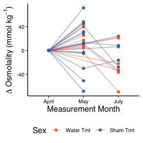

```r
ggplot(dat_tmt_change) +
  aes(x = month,
      y = osml_change_from_April,
      group = individual_ID,
      color = tmt
      ) +
  xlab("Measurement Month") +
  ylab(expression(Delta ~ 'Osmolality (mmol '*kg^-1*')')) +
  geom_line(alpha = 0.5) +
  geom_point(size = 1.5) +
  scale_color_manual(values = my_colors, name = "Sex") +
  savs_ggplot_theme -> tmt_delta_osml
tmt_delta_osml
```

### CEWL

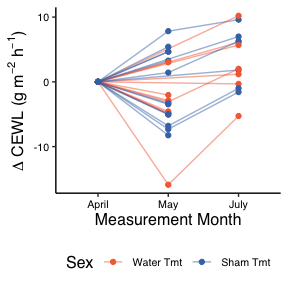

```r
ggplot(dat_tmt_change) +
  aes(x = month,
      y = CEWL_change_from_April,
      group = individual_ID,
      color = tmt
      ) +
  xlab("Measurement Month") +
  ylab(expression(Delta ~ 'CEWL (g '*m^-2*' '*h^-1*')')) +
  geom_line(alpha = 0.5) +
  geom_point(size = 1.5) +
  scale_color_manual(values = my_colors, name = "Sex") +
  savs_ggplot_theme -> tmt_delta_CEWL
tmt_delta_CEWL
```

It does *not* look like treatment led to any differences in the amount or direction of change in lizard mass, CEWL, or osmolality. Changes were also not consistent by sex.

## Export Multi-Panel Fig

Save plots:

[figure not shown]

```r
ggarrange(tmt_delta_CEWL,
          tmt_delta_osml,
          tmt_delta_mass,
          ncol = 1, nrow = 3,
          labels = c("A", "B", "C"),
          common.legend = TRUE,
          legend = "bottom"
          ) -> tmt_delta_multi_fig
tmt_delta_multi_fig
```

## Tmt Marginal Means

I want to know whether the average values for the lizards we measured changes over time based on supplemental hydration treatment. To test this, I can run a linear model, then use emmeans to get the marginal means and confidence intervals for each time point.

**Do this only for lizards with repeat measurements, because those are the ones that received tmt.**

### Mass

```r
tmt_diffs_mass <- lmerTest::lmer(data = dat_repeats, mass_g ~ month*tmt +
                                        (1|individual_ID))
```

```
## fixed-effect model matrix is rank deficient so dropping 1 column / coefficient
```

```r
anova(tmt_diffs_mass, type = "3", ddf = "Kenward-Roger")
```

```
## Missing cells for: monthJuly:tmtNo Tmt.
## Interpret type III hypotheses with care.
```

```
## Type III Analysis of Variance Table with Kenward-Roger's method
##            Sum Sq Mean Sq NumDF  DenDF F value   Pr(>F)
## month     274.074 137.037     2 37.802  7.4633 0.001854 **
## tmt       224.282 112.141     2 32.029  6.1078 0.005661 **
## month:tmt  37.189  12.396     3 37.177  0.6751 0.572776
## ---
## Signif. codes:  0 '***' 0.001 '**' 0.01 '*' 0.05 '.' 0.1 ' ' 1
```

```r
# mean values
(emmeans(tmt_diffs_mass, pairwise ~ month | tmt)$emmean)
```

```
## tmt = Water Tmt:
##  month emmean   SE   df lower.CL upper.CL
##  April   41.0 2.03 45.7     37.0     45.1
##  May     46.1 2.26 56.7     41.6     50.6
##  July    37.6 2.34 59.7     32.9     42.3
##
## tmt = Sham Tmt:
##  month emmean   SE   df lower.CL upper.CL
##  April   37.9 1.92 43.5     34.1     41.8
##  May     39.7 1.99 47.8     35.7     43.7
##  July    34.9 2.53 65.4     29.9     40.0
##
## tmt = No Tmt:
##  month emmean   SE   df lower.CL upper.CL
##  April   29.8 3.33 43.5     23.1     36.5
##  May     31.8 3.33 43.5     25.1     38.5
##  July  nonEst   NA   NA       NA       NA
##
## Degrees-of-freedom method: kenward-roger
## Confidence level used: 0.95
```

```r
# stat diffs by month
(emmeans(tmt_diffs_mass, pairwise ~ month | tmt)$contrasts)
```

```
## tmt = Water Tmt:
##  contrast     estimate   SE   df t.ratio p.value
##  April - May     -5.05 1.99 37.6  -2.542  0.0395
##  April - July     3.45 2.09 38.3   1.652  0.2369
##  May - July       8.50 2.44 41.5   3.480  0.0033
##
## tmt = Sham Tmt:
##  contrast     estimate   SE   df t.ratio p.value
##  April - May     -1.76 1.65 35.7  -1.066  0.5412
##  April - July     2.99 2.27 38.4   1.314  0.3964
##  May - July       4.75 2.41 39.9   1.970  0.1328
##
## tmt = No Tmt:
##  contrast     estimate   SE   df t.ratio p.value
##  April - May     -2.00 2.71 35.0  -0.738  0.7428
##  April - July   nonEst   NA   NA      NA      NA
##  May - July     nonEst   NA   NA      NA      NA
##
## Degrees-of-freedom method: kenward-roger
## P value adjustment: tukey method for comparing a family of 3 estimates
```

```r
# stat diffs by tmt
(emmeans(tmt_diffs_mass, pairwise ~ tmt | month)$contrasts)
```

```
## month = April:
##  contrast             estimate   SE   df t.ratio p.value
##  Water Tmt - Sham Tmt     3.12 2.79 44.7   1.116  0.5096
##  Water Tmt - No Tmt      11.25 3.90 44.1   2.885  0.0163
##  Sham Tmt - No Tmt        8.13 3.85 43.5   2.115  0.0984
##
## month = May:
##  contrast             estimate   SE   df t.ratio p.value
##  Water Tmt - Sham Tmt     6.40 3.01 52.9   2.127  0.0940
##  Water Tmt - No Tmt      14.30 4.02 47.7   3.554  0.0024
##  Sham Tmt - No Tmt        7.89 3.88 44.7   2.033  0.1159
##
## month = July:
##  contrast             estimate   SE   df t.ratio p.value
##  Water Tmt - Sham Tmt     2.65 3.45 63.4   0.769  0.7234
##  Water Tmt - No Tmt     nonEst   NA   NA      NA      NA
##  Sham Tmt - No Tmt      nonEst   NA   NA      NA      NA
##
## Degrees-of-freedom method: kenward-roger
## P value adjustment: tukey method for comparing a family of 3 estimates
```

### Body Condition

```r
tmt_diffs_SMI <- lmerTest::lmer(data = dat_repeats, SMI ~ month*tmt +
                                        (1|individual_ID))
```

```
## fixed-effect model matrix is rank deficient so dropping 1 column / coefficient
```

```r
anova(tmt_diffs_SMI, type = "3", ddf = "Kenward-Roger")
```

```
## Missing cells for: monthJuly:tmtNo Tmt.
## Interpret type III hypotheses with care.
```

```
## Type III Analysis of Variance Table with Kenward-Roger's method
##            Sum Sq Mean Sq NumDF  DenDF F value    Pr(>F)
## month     282.941 141.470     2 43.652 10.7878 0.0001559 ***
## tmt        42.122  21.061     2 33.543  1.6068 0.2155784
## month:tmt  45.205  15.068     3 41.791  1.1490 0.3405994
## ---
## Signif. codes:  0 '***' 0.001 '**' 0.01 '*' 0.05 '.' 0.1 ' ' 1
```

```r
# mean values
(emmeans(tmt_diffs_SMI, pairwise ~ month | tmt)$emmean)
```

```
## tmt = Water Tmt:
##  month emmean   SE   df lower.CL upper.CL
##  April   34.7 1.11 64.2     32.4     36.9
##  May     39.6 1.34 65.9     37.0     42.3
##  July    31.2 1.42 66.0     28.4     34.1
##
## tmt = Sham Tmt:
##  month emmean   SE   df lower.CL upper.CL
##  April   34.2 1.04 63.4     32.2     36.3
##  May     36.2 1.11 64.8     33.9     38.4
##  July    31.5 1.64 65.3     28.2     34.8
##
## tmt = No Tmt:
##  month emmean   SE   df lower.CL upper.CL
##  April   33.4 1.79 63.4     29.8     37.0
##  May     34.4 1.79 63.4     30.8     38.0
##  July  nonEst   NA   NA       NA       NA
##
## Degrees-of-freedom method: kenward-roger
## Confidence level used: 0.95
```

```r
# stat diffs by month
(emmeans(tmt_diffs_SMI, pairwise ~ month | tmt)$contrasts)
```

```
## tmt = Water Tmt:
##  contrast     estimate   SE   df t.ratio p.value
##  April - May     -4.99 1.62 43.0  -3.077  0.0100
##  April - July     3.42 1.69 44.8   2.022  0.1186
##  May - July       8.41 1.89 54.6   4.439  0.0001
##
## tmt = Sham Tmt:
##  contrast     estimate   SE   df t.ratio p.value
##  April - May     -1.94 1.38 37.3  -1.400  0.3514
##  April - July     2.70 1.84 46.7   1.471  0.3141
##  May - July       4.64 1.91 51.4   2.430  0.0481
##
## tmt = No Tmt:
##  contrast     estimate   SE   df t.ratio p.value
##  April - May     -1.03 2.29 35.5  -0.449  0.8953
##  April - July   nonEst   NA   NA      NA      NA
##  May - July     nonEst   NA   NA      NA      NA
##
## Degrees-of-freedom method: kenward-roger
## P value adjustment: tukey method for comparing a family of 3 estimates
```

```r
# stat diffs by tmt
(emmeans(tmt_diffs_SMI, pairwise ~ tmt | month)$contrasts)
```

```
## month = April:
##  contrast             estimate   SE   df t.ratio p.value
##  Water Tmt - Sham Tmt    0.429 1.52 63.9   0.282  0.9572
##  Water Tmt - No Tmt      1.265 2.11 63.6   0.599  0.8211
##  Sham Tmt - No Tmt       0.837 2.07 63.4   0.404  0.9142
##
## month = May:
##  contrast             estimate   SE   df t.ratio p.value
##  Water Tmt - Sham Tmt    3.479 1.74 65.6   1.997  0.1210
##  Water Tmt - No Tmt      5.224 2.24 64.6   2.332  0.0584
##  Sham Tmt - No Tmt       1.745 2.11 63.8   0.826  0.6881
##
## month = July:
##  contrast             estimate   SE   df t.ratio p.value
##  Water Tmt - Sham Tmt   -0.291 2.17 65.8  -0.134  0.9901
##  Water Tmt - No Tmt     nonEst   NA   NA      NA      NA
##  Sham Tmt - No Tmt      nonEst   NA   NA      NA      NA
##
## Degrees-of-freedom method: kenward-roger
## P value adjustment: tukey method for comparing a family of 3 estimates
```

### Osmolality

```r
tmt_diffs_osml <- lmerTest::lmer(data = dat_repeats,
                                      osmolality_mmol_kg_mean ~ month*tmt +
                                        (1|individual_ID))
```

```
## fixed-effect model matrix is rank deficient so dropping 1 column / coefficient
```

```r
anova(tmt_diffs_osml, type = "3", ddf = "Kenward-Roger")
```

```
## Missing cells for: monthJuly:tmtNo Tmt.
## Interpret type III hypotheses with care.
```

```
## Type III Analysis of Variance Table with Kenward-Roger's method
##           Sum Sq Mean Sq NumDF  DenDF F value  Pr(>F)
## month     4511.6 2255.81     2 43.087  4.6155 0.01527 *
## tmt        343.7  171.85     2 33.790  0.3518 0.70600
## month:tmt  823.2  274.41     3 41.048  0.5614 0.64352
## ---
## Signif. codes:  0 '***' 0.001 '**' 0.01 '*' 0.05 '.' 0.1 ' ' 1
```

```r
# mean values
(emmeans(tmt_diffs_osml, pairwise ~ month | tmt)$emmean)
```

```
## tmt = Water Tmt:
##  month emmean    SE   df lower.CL upper.CL
##  April    356  7.18 62.4      342      371
##  May      379  8.29 63.8      363      396
##  July     345  8.80 64.0      327      362
##
## tmt = Sham Tmt:
##  month emmean    SE   df lower.CL upper.CL
##  April    364  6.42 60.8      351      377
##  May      375  6.90 62.5      361      389
##  July     359 10.14 63.2      339      379
##
## tmt = No Tmt:
##  month emmean    SE   df lower.CL upper.CL
##  April    368 12.45 62.6      343      392
##  May      376 11.13 60.8      354      399
##  July  nonEst    NA   NA       NA       NA
##
## Degrees-of-freedom method: kenward-roger
## Confidence level used: 0.95
```

```r
# stat diffs by month
(emmeans(tmt_diffs_osml, pairwise ~ month | tmt)$contrasts)
```

```
## tmt = Water Tmt:
##  contrast     estimate    SE   df t.ratio p.value
##  April - May    -23.01 10.04 39.7  -2.291  0.0687
##  April - July    11.58 10.62 45.6   1.090  0.5249
##  May - July      34.59 11.65 52.8   2.969  0.0122
##
## tmt = Sham Tmt:
##  contrast     estimate    SE   df t.ratio p.value
##  April - May    -10.87  8.45 35.5  -1.286  0.4122
##  April - July     4.80 11.25 44.2   0.427  0.9048
##  May - July      15.67 11.71 48.6   1.338  0.3812
##
## tmt = No Tmt:
##  contrast     estimate    SE   df t.ratio p.value
##  April - May     -8.74 15.05 37.3  -0.580  0.8314
##  April - July   nonEst    NA   NA      NA      NA
##  May - July     nonEst    NA   NA      NA      NA
##
## Degrees-of-freedom method: kenward-roger
## P value adjustment: tukey method for comparing a family of 3 estimates
```

```r
# stat diffs by tmt
(emmeans(tmt_diffs_osml, pairwise ~ tmt | month)$contrasts)
```

```
## month = April:
##  contrast             estimate    SE   df t.ratio p.value
##  Water Tmt - Sham Tmt    -7.53  9.64 61.8  -0.781  0.7159
##  Water Tmt - No Tmt     -11.11 14.38 62.5  -0.773  0.7208
##  Sham Tmt - No Tmt       -3.58 14.01 62.3  -0.256  0.9646
##
## month = May:
##  contrast             estimate    SE   df t.ratio p.value
##  Water Tmt - Sham Tmt     4.61 10.79 63.4   0.427  0.9045
##  Water Tmt - No Tmt       3.16 13.88 62.2   0.227  0.9719
##  Sham Tmt - No Tmt       -1.45 13.09 61.4  -0.111  0.9933
##
## month = July:
##  contrast             estimate    SE   df t.ratio p.value
##  Water Tmt - Sham Tmt   -14.31 13.42 63.8  -1.066  0.5384
##  Water Tmt - No Tmt     nonEst    NA   NA      NA      NA
##  Sham Tmt - No Tmt      nonEst    NA   NA      NA      NA
##
## Degrees-of-freedom method: kenward-roger
## P value adjustment: tukey method for comparing a family of 3 estimates
```